# Boston Crime Analysis - Machine Learning

James Park

12/5/2018

# Objective

The objective of this portion is quantitative prediction. In this project, we will explore four approaches to supervised maching learning. The first modeling choices we make are to use regression instead of classification to include more flexible models at the expense of interpretability. As we deal with count data, we will use a poisson distribution. We will compare the outcomes of the following models:

#### 1.Random gorest using ‘ranger’

#### 2.Generalized linear model using ‘glm’

#### 3.Stochastic gradient boosting using ‘gbm’

#### 4.Cubist using ‘cubist’

```r
# installing required packages
lib <- c("tidyverse", "ggthemes", "caret", "rpart", "rpart.plot", "modelr", "gridExtra",
         "lubridate", "broom","stringr")

lapply(lib, require, character.only = TRUE)
```

We will explore the data by focusing on the 9 major crime categories in the Boston districts. The dataset covers from 2015/06 to 2018/11.

```r
df <- read.csv("crime.csv")
# Exploratory analysis 1
# Color can handle a maximum of 9 values; analysis is limited to 9 major crime codes
offense <- as.data.frame(table(df$OFFENSE_CODE_GROUP)) # list all the counts
offense <- offense[order(offense$Freq),]
offense <- offense[59:67,] # Most frequent offense
names <- c("Verbal Disputes", "Vandalism", "Simple Assault",
  "Drug Violation", "Other", "Investigate Person",
  "Medical Assistance", "Larceny", "Motor Vehicle Accident Response")

only9 <- df[df$OFFENSE_CODE_GROUP %in% names,] # dataframe with only 9 crimes
factor(only9$OFFENSE_CODE_GROUP) # drop the factor names
```

# Reusable objects

## Training control

Repeated k-fold cross-validation is used as it is well-known with models generally irrespective of their fitting procedures. The observations are split into “k” equally separated folds for each model. This balance is used for training the model. This ‘train_contol’ variable is used as our training control so we can reuse these parameters with each of our regression models.

```r
train_control <-
  trainControl(
    method = "repeatedcv",
    number = 10,
    repeats = 5,
    allowParallel = TRUE,
    seeds = c(1:51)
  )

# reusable theme for model predictions
theme_thinkr <- theme_economist() + theme(
  rect = element_rect(fill = "#f9f5f1"),
  plot.title = element_text(size = 12),
  plot.subtitle = element_text(size = 6),
  strip.text = element_text(size = 9),
  axis.text.x = element_text(size = 7),
  legend.text = element_text(size = 7),
  plot.background = element_rect(fill = "#f9f5f1")
)

# our wrangled final data frame
only9 <- df[df$OFFENSE_CODE_GROUP %in% names,]

crime <-
  only9 %>%
  select(YEAR, MONTH, DISTRICT, OFFENSE_CODE_GROUP) %>%
  mutate(
    year=factor(YEAR),
    month=factor(MONTH),
    maj_cat=factor(OFFENSE_CODE_GROUP),
    borough=factor(DISTRICT)
  ) %>%
  filter(!(borough == "")) %>%
  group_by(year, month, borough, maj_cat) %>%
  summarise(count = n())
```

# Generalized Linear Model

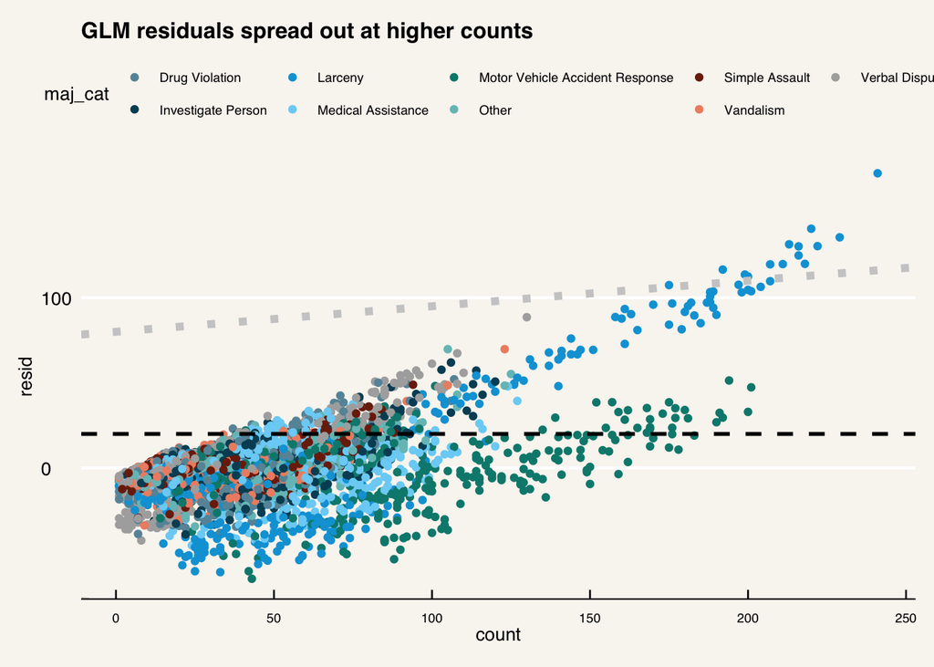

```r
## glm
gather_residuals(crime, model_GLM, .resid = "resid", .model = "model") %>%
  ggplot(aes(count, resid, colour = maj_cat)) +
  geom_point() +
  ggtitle("GLM residuals spread out at higher counts") +
  geom_hline(yintercept = 20, lty = 2, size = 1) +
  geom_abline(intercept = 80, slope = 0.15, colour = "grey80", size = 2, lty = 3) +
  geom_abline(intercept = -80, slope = -0.17, colour = "grey80", size = 2, lty = 3) +
  scale_colour_economist() +
  theme_thinkr
```

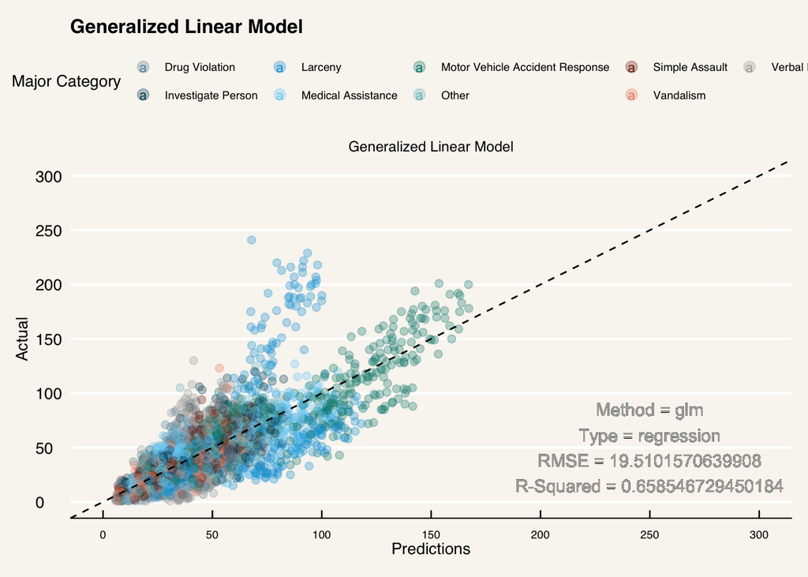

```r
crime %>%
  spread_predictions("Generalized Linear Model" = model_GLM) %>%
  gather(key = model,
         value = pred,-year,-month,-borough,-maj_cat,-count) %>%
  rename(act = count) %>%
  ggplot(aes(pred, act, colour = maj_cat)) +
  geom_point(alpha = 0.3, size = 2) +
  geom_abline(colour = "black", lty = 2) +
  geom_text(
    x = 250,
    y = 50,
    aes(
      label = paste0(
        "Method = glm","\n",
        "Type = regression","\n",
        "RMSE = ",
        model_GLM$results$RMSE,"\n",
        "R-Squared = ",
        model_GLM$results$Rsquared)
      )) +
  facet_wrap( ~ model) +
  scale_colour_economist(name = "Major Category") +
  scale_y_continuous(breaks = seq(0, 300, by = 50),
                     limits = c(0, 300)) +
  scale_x_continuous(breaks = seq(0, 300, by = 50),
                     limits = c(0, 300)) +
  ggtitle("Generalized Linear Model") +
  labs(x = "Predictions", y = "Actual") +
  guides(colour = guide_legend(override.aes = list(size = 3))) +
  theme_thinkr
```

By plotting the residuals of the GLM model, an increasing spread is shown as the count gets larger.

# Recursive partitioning

We will run a recursive partitioning model using the caret package to tune and refine the model. This will create consistent outputs across the four models, which will help us to pull useful information out of the final models to annotate the final plot.

```r
tune_grid <-
  expand.grid(
    cp = 0.00001
    )

model_RP <-
  train(
    count ~ .,  # the effect of interacting term is negligible in this model
    data = crime,
    method = "rpart",
    metric = "RMSE",
    parms = list(method = "poisson"),
    tuneGrid = tune_grid,
    trControl = train_control
    )
```

# Random Forest

Random Forest combines many decision trees by spliting the training data horizontally. Then, random forest randomly samples the predictors verically.

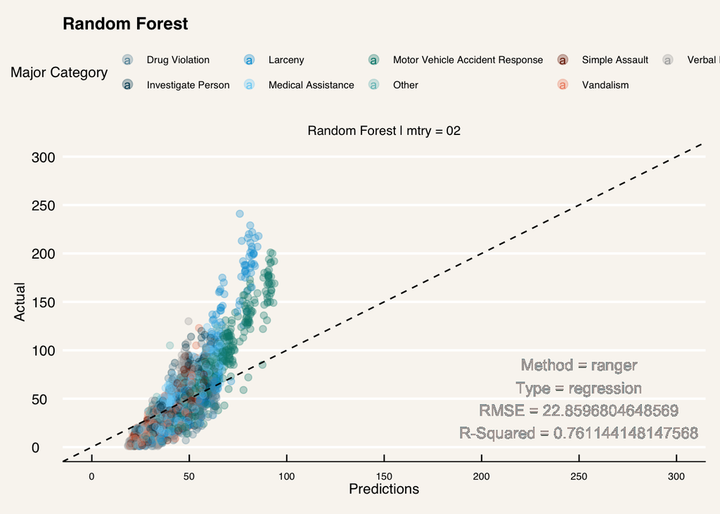

```r
tune_grid <-
  expand.grid(
    mtry = 2,
    splitrule = "variance",
    min.node.size = 5
  )

model_RF2 <-
  train(
    count ~ .,
    data = crime,
    method = "ranger",
    num.trees = 500,
    metric = "RMSE",
    respect.unordered.factors = TRUE,
    tuneGrid = tune_grid,
    trControl = train_control
  )


crime %>%
  spread_predictions("Random Forest | mtry = 02" = model_RF2) %>%
  gather(key = model,
         value = pred,-year,-month,-borough,-maj_cat,-count) %>%
  rename(act = count) %>%
  ggplot(aes(pred, act, colour = maj_cat)) +
  geom_point(alpha = 0.3, size = 2) +
  geom_abline(colour = "black", lty = 2) +
  geom_text(
    x = 250,
    y = 50,
    aes(
      label = paste0(
        "Method = ranger","\n",
        "Type = regression","\n",
        "RMSE = ",
        model_RF2$results$RMSE,"\n",
        "R-Squared = ",
        model_RF2$results$Rsquared)
      )) +
  facet_wrap( ~ model) +
  scale_colour_economist(name = "Major Category") +
  scale_y_continuous(breaks = seq(0, 300, by = 50),
                     limits = c(0, 300)) +
  scale_x_continuous(breaks = seq(0, 300, by = 50),
                     limits = c(0, 300)) +
  ggtitle("Random Forest") +
  labs(x = "Predictions", y = "Actual") +
  guides(colour = guide_legend(override.aes = list(size = 3))) +
  theme_thinkr
```

# Stochastic Gradient Boosting

Stochastic gradient boosting is another useful way to improve our predictions from decisions trees as it is better with natural selection with fitter successive trees.

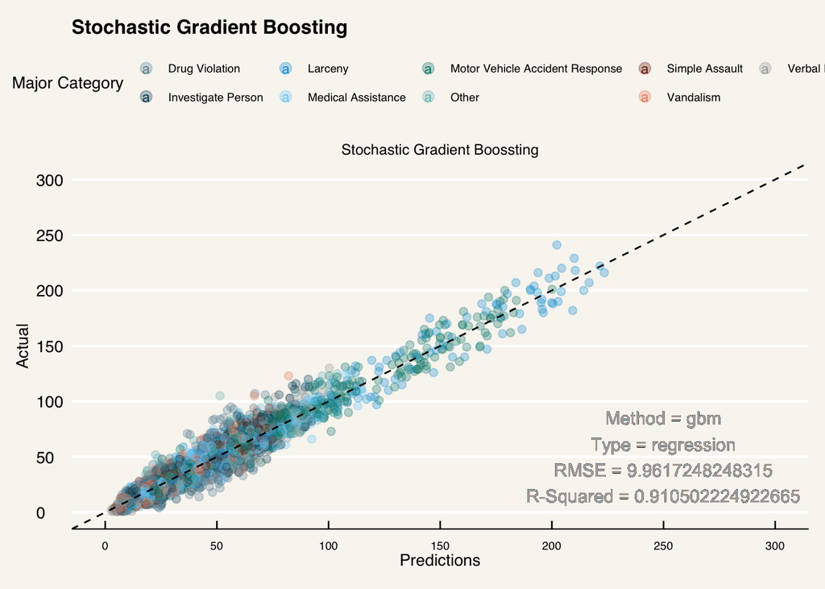

```r
tune_grid <-
  expand.grid(
    interaction.depth = 10,
    n.trees = 500,
    shrinkage = 0.1,
    n.minobsinnode = 5
  )

model_SGB <-
  train(
    count ~ .,
    data = crime,
    distribution = "poisson",
    method = "gbm",
    metric = "RMSE",
    tuneGrid = tune_grid,
    verbose = FALSE,
    bag.fraction = 0.5,
    trControl = train_control
  )

crime %>%
  spread_predictions("Stochastic Gradient Boossting" = model_SGB) %>%
  gather(key = model,
         value = pred,-year,-month,-borough,-maj_cat,-count) %>%
  rename(act = count) %>%
  ggplot(aes(pred, act, colour = maj_cat)) +
  geom_point(alpha = 0.3, size = 2) +
  geom_abline(colour = "black", lty = 2) +
  geom_text(
    x = 250,
    y = 50,
    aes(
      label = paste0(
        "Method = gbm","\n",
        "Type = regression","\n",
        "RMSE = ",
        model_SGB$results$RMSE,"\n",
        "R-Squared = ",
        model_SGB$results$Rsquared)
      )) +
  facet_wrap( ~ model) +
  scale_colour_economist(name = "Major Category") +
  scale_y_continuous(breaks = seq(0, 300, by = 50),
                     limits = c(0, 300)) +
  scale_x_continuous(breaks = seq(0, 300, by = 50),
                     limits = c(0, 300)) +
  ggtitle("Stochastic Gradient Boosting") +
  labs(x = "Predictions", y = "Actual") +
  guides(colour = guide_legend(override.aes = list(size = 3))) +
  theme_thinkr
```